# Informe Final

Ana Julia Escobar

3 de agosto de 2015

### Introducción

Análisis de nuestro modelo de regresión lineal múltiple.

### Descripción información

Cargamos nuestras datas

```r
options(warn=-1)
library(readxl)
pob1<-read_excel("poblacion1.xlsx", sheet=1, na=" ")
pob2<-read_excel("poblacion2.xlsx", sheet=1, na=" ")
View(pob1)
str(pob1)
```

```
## Classes 'tbl_df', 'tbl' and 'data.frame':    44 obs. of  4 variables:
##  $ identificador : num  1001 1002 1003 1004 1005 ...
##  $ poblacion     : num  18.7 13.8 13.4 11.4 10.5 10.3 10.3 10.3 10.3 9.4 ...
##  $ var.pobl.mayor: num  6.2 7.2 7.1 2.6 2.8 1.4 -0.5 3 -1.9 -1.5 ...
##  $ menores.18    : num  39.7 10.4 20.4 38.7 36.4 29.8 31.8 31.1 15.9 22.4 ...
```

```r
View(pob2)
str(pob2)
```

```
## Classes 'tbl_df', 'tbl' and 'data.frame':    40 obs. of  7 variables:
##  $ identificador  : num  1044 1042 1010 1009 1008 ...
##  $ part.almz.escl : num  73.8 34.4 22.2 39.9 51.7 57.2 43.7 72.3 78.2 13.9 ...
##  $ var.ingresos   : num  50.5 24.2 33.5 38.5 26.2 27.2 29.4 26 18.4 22.5 ...
##  $ tasa.crimen    : num  704.1 179.9 61.5 86.4 42.4 ...
##  $ var.tasa.crimen: num  -40.9 12.3 -32.7 -13.5 -31.9 -17.6 -10 -21.6 -12.8 -33.6 ...
##  $ region         : chr  "B" "B" "A" "A" ...
##  $ serv.bas.compl : chr  "SI" "NO" "NO" "SI" ...
```

Disponemos de 44 observaciones de 4 variables. Disponemos de 40 observaciones de 7 variables.

Tendremos nuestras datas en una: población.

```r
options(warn=-1)
poblacion <- merge(pob1,pob2,by="identificador",suffixes=c("",""))
str(poblacion)
```

```
## 'data.frame':    40 obs. of  10 variables:
##  $ identificador  : num  1001 1002 1003 1004 1005 ...
##  $ poblacion      : num  18.7 13.8 13.4 11.4 10.5 10.3 10.3 10.3 10.3 9.4 ...
##  $ var.pobl.mayor : num  6.2 7.2 7.1 2.6 2.8 1.4 -0.5 3 -1.9 -1.5 ...
##  $ menores.18     : num  39.7 10.4 20.4 38.7 36.4 29.8 31.8 31.1 15.9 22.4 ...
##  $ part.almz.escl : num  55.8 57.9 13.9 78.2 72.3 43.7 57.2 51.7 39.9 22.2 ...
##  $ var.ingresos   : num  28.7 26.2 22.5 18.4 26 29.4 27.2 26.2 38.5 33.5 ...
##  $ tasa.crimen    : num  52.6 111 38.3 86.6 77.5 54 61.2 42.4 86.4 61.5 ...
##  $ var.tasa.crimen: num  -2.9 -22.6 -33.6 -12.8 -21.6 -10 -17.6 -31.9 -13.5 -32.7 ...
##  $ region         : chr  "A" "A" "A" "A" ...
##  $ serv.bas.compl : chr  "SI" "SI" "NO" "NO" ...
```

### Modelo de regresión lineal simple

Explicaremos la variable poblacion en función de los regresores que tengan mayor correlación con nuestra variable dependiente.

```r
options(warn=-1)
core <- 3:dim(poblacion)[2]
core[1] <- NA


for(i in 2:dim(poblacion)[2]){
  if(is.numeric(poblacion[,i])==TRUE){
    core[i] <- cor(poblacion[,2], poblacion[,i])
  } else {
    core[i] <- NA
  }
}
core
```

```
##  [1]          NA  1.00000000 -0.15774031  0.19709059 -0.04686172
##  [6] -0.07677708 -0.37492254 -0.07645301          NA          NA
```

Ajustamos un modelo de regresión lineal múltiple para las variables poblacion con var.pobl.mayor, menores.18, tasa.crimen

La regresion regresión.

```r
reg <- lm(poblacion~var.pobl.mayor+menores.18+tasa.crimen, data=poblacion)
summary(reg)
```

```
##
## Call:
## lm(formula = poblacion ~ var.pobl.mayor + menores.18 + tasa.crimen,
##     data = poblacion)
##
## Residuals:
##     Min      1Q  Median      3Q     Max
## -5.0239 -2.6986 -0.3656  2.0947 10.2333
##
## Coefficients:
##                 Estimate Std. Error t value Pr(>|t|)
## (Intercept)     7.388436   2.048573   3.607 0.000933 ***
## var.pobl.mayor  0.029694   0.082263   0.361 0.720238
## menores.18      0.039498   0.064026   0.617 0.541179
## tasa.crimen    -0.012813   0.006367  -2.012 0.051730 .
## ---
## Signif. codes:  0 '***' 0.001 '**' 0.01 '*' 0.05 '.' 0.1 ' ' 1
##
## Residual standard error: 3.468 on 36 degrees of freedom
## Multiple R-squared:  0.1533, Adjusted R-squared:  0.08277
## F-statistic: 2.173 on 3 and 36 DF,  p-value: 0.1081
```

Es decir nuestro modelo resultante estaría dado por la expresión $\hat{po} = 7.3884361 + 0.0296939 \hat{va}+0.0394981 \hat{me} -0.0128125 \hat{ta}$

### Interpretación

**Interpretación modelo:** Si var.pobl.mayor se incrementa en una unidad, entonces poblacion aumenta en promedio 0.0296939 unidades.

Si menores.18 se incrementa en una unidad, entonces poblacion aumenta en promedio 0.0394981 unidades._

Si tasa.crimen se incrementa en una unidad, entonces poblacion disminuye en promedio 0.0128125 unidades.

**Interpretación $R^2$:**

El modelo de regresión lineal obtenido explica el 15.3323897111369 % de la variabilidad total.

### Pruebas de hipótesis

Para $\beta_4$ Como $t=-2.0121753$ es menor que $t_{38}(\frac{\alpha}{2})= 2.0243942$ no rechazo $H_0: \beta_4=0$.

Para $\beta_3$ Como $t=0.6169066$ es menor que $t_{38}(\frac{\alpha}{2})= 2.0243942$ no rechazo $H_0: \beta_3=0$.

Para $\beta_2$ Como $t=0.3609615$ es menor que $t_{38}(\frac{\alpha}{2})= 2.0243942$ no rechazo $H_0: \beta_2=0$.

Para $\beta_1$ Como $t=3.6066254$ es mayor que $t_{38}(\frac{\alpha}{2})= 2.0243942$ rechazo $H_0: \beta_1=0$.

### Análisis de varianza

Realizando la tabla **ANOVA** tenemos los siguientes resultados:

```r
anova <- aov(reg)
summary(anova)
```

```
##                Df Sum Sq Mean Sq F value Pr(>F)
## var.pobl.mayor  1   12.7   12.73   1.058 0.3105
## menores.18      1   17.0   16.99   1.412 0.2424
## tasa.crimen     1   48.7   48.70   4.049 0.0517 .
## Residuals      36  433.0   12.03
## ---
## Signif. codes:  0 '***' 0.001 '**' 0.01 '*' 0.05 '.' 0.1 ' ' 1
```

### Intervalos de confianza

```r
confint(reg,level = 0.95)
```

```
##                      2.5 %       97.5 %
## (Intercept)     3.23373707 1.154314e+01
## var.pobl.mayor -0.13714393 1.965317e-01
## menores.18     -0.09035265 1.693488e-01
## tasa.crimen    -0.02572639 1.013625e-04
```

### Gráficos residuales

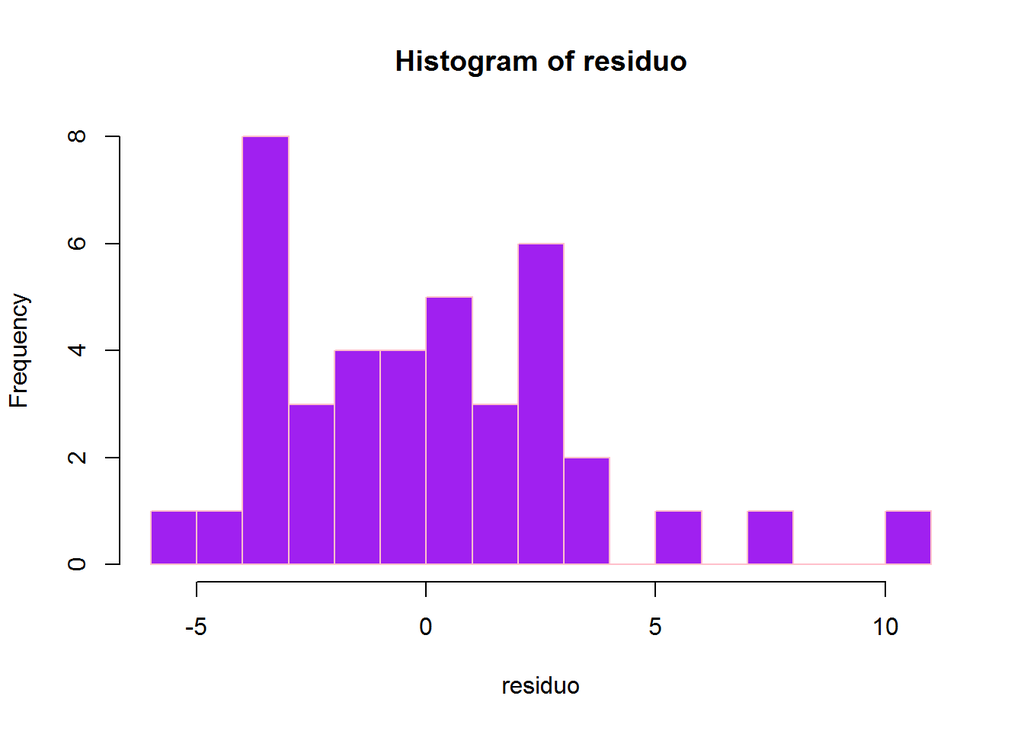

```r
library(DT)
residuo <- reg[["residuals"]]
prediccion <- reg[["fitted.values"]]
hist(residuo,15,col = "purple",border = "pink")
```

```r
mean(residuo)
```

```
## [1] -1.394284e-16
```

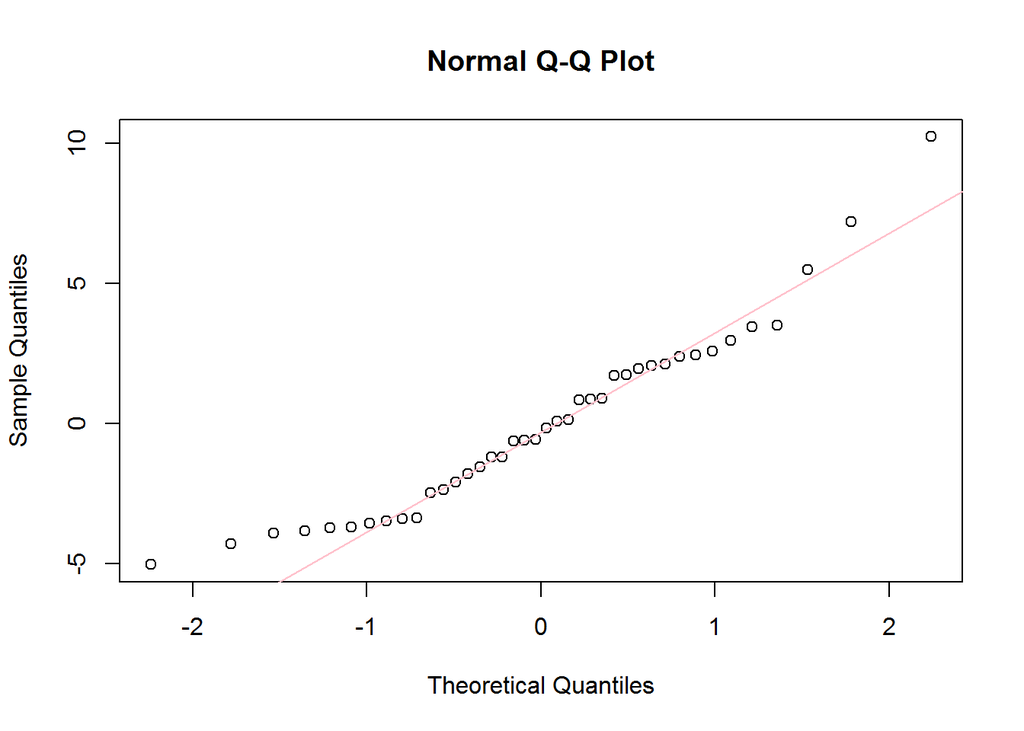

```r
qqnorm(residuo)
qqline(residuo,col="pink")
```